# Case Study -Term Deposit Sale Prediction

# Dataset:

The historical data for this project is available in file https://archive.ics.uci.edu/ml/datasets/Bank+Marketing

# Problem Statement:

Using the data collected from existing customers, build a model that will help the marketing team identify potential customers who are relatively more likely to subscribe term deposit and thus increase their hit ratio.

### Deliverable – 1 (Exploratory data quality report reflecting the following) – (20)

1. Univariate analysis (12 marks) a. Univariate analysis – data types and description of the independent attributes which should include (name, meaning, range of values observed, central values (mean and median), standard deviation and quartiles, analysis of the body of distributions / tails, missing values, outliers. b. Strategies to address the different data challenges such as data pollution, outlier’s treatment and missing values treatment. c. Please provide comments in jupyter notebook regarding the steps you take and insights drawn from the plots.
2. Multivariate analysis (8 marks) a. Bi-variate analysis between the predictor variables and target column. Comment on your findings in terms of their relationship and degree of relation if any.
   - Visualize the analysis using boxplots and pair plots, histograms or density curves.
   - Select the most appropriate attributes. b. Please provide comments in jupyter notebook regarding the steps you take and insights drawn from the plots

### Deliverable – 2 (Prepare the data for analytics) – (10)

1. Ensure the attribute types are correct. If not, take appropriate actions.
2. Get the data model ready.
3. Transform the data i.e. scale / normalize if required
4. Create the training set and test set in ratio of 70:30

### Deliverable – 3 (create the ensemble model) – (30)

1. First create models using Logistic Regression and Decision Tree algorithm. Note the model performance by using different matrices. Use confusion matrix to evaluate class level metrics i.e. Precision/Recall. Also reflect the accuracy and F1 score of the model. (10 marks)
2. Build the ensemble models (Bagging and Boosting) and note the model performance by using different matrices. Use same metrics as in above model. (at least 3 algorithms) (15 marks)
3. Make a DataFrame to compare models and their metrics. Give conclusion regarding the best algorithm and your reason behind it. (5 marks)

## Attribute information:

Input variables: Bank client data:

1. age: Continuous feature
2. job: Type of job (management, technician, entrepreneur, blue-collar, etc.)
3. marital: marital status (married, single, divorced)
4. education: education level (primary, secondary, tertiary)
5. default: has credit in default?
6. housing: has housing loan?
7. loan: has personal loan?
8. balance in account

Related to previous contact:

1. contact: contact communication type
2. month: last contact month of year
3. day: last contact day of the month
4. duration: last contact duration, in seconds*

Other attributes:

1. campaign: number of contacts performed during this campaign and for this client
2. pdays: number of days that passed by after the client was last contacted from a previous campaign (-1 tells us the person has not been contacted or contact period is beyond 900 days)
3. previous: number of times the client has been contacted before for the last campaign to subscribe term deposit
4. poutcome: outcome of the previous marketing campaign Output variable (desired target):
5. Target: Tell us has the client subscribed a term deposit. (Yes, No)

# Import all necessary modules and load the data

```python
import numpy as np
import pandas as pd

import matplotlib.pyplot as plt
import seaborn as sns
import pandas_profiling

from sklearn.model_selection import train_test_split
from sklearn.tree import DecisionTreeClassifier
from sklearn.metrics import accuracy_score, f1_score, recall_score, precision_score, confusion_matrix

#from yellowbrick.classifier import ClassificationReport, ROCAUC

plt.style.use('ggplot')
pd.options.display.float_format = '{:,.2f}'.format
from IPython.core.display import display, HTML
display(HTML("<style>.container { width:95% !important; }</style>"))

#For numerical libraries
import numpy as np

#To handle data in the form of rows and columns
import pandas as pd

#importing seaborn for statistical plots
import seaborn as sns

#importing ploting libraries
import matplotlib.pyplot as plt

#styling figures
plt.rc('font',size=14)
sns.set(style='white')
sns.set(style='whitegrid',color_codes=True)

#To enable plotting graphs in Jupyter notebook
%matplotlib inline

#importing the Encoding library
from sklearn.preprocessing import LabelEncoder

#Import Decision Tree Classifier machine learning Library
from sklearn.tree import DecisionTreeClassifier

# Import Logistic Regression machine learning library
from sklearn.linear_model import LogisticRegression

#Import Naive Bayes' machine learning Library
from sklearn.naive_bayes import GaussianNB

#Import Sklearn package's data splitting function which is based on random function
from sklearn.model_selection import train_test_split

#Import the metrics
from sklearn import metrics

#Import the Voting classifier for Ensemble
from sklearn.ensemble import VotingClassifier
```

```python
df = pd.read_csv('bank-full.csv')
```

# Print first 10 observations from the dataset

```python
df.head(10)
```

|  | age | job | marital | education | default | balance | housing | loan | contact | day | month | duration | campaign | pdays | previous | poutcome | Target |
| --- | --- | --- | --- | --- | --- | --- | --- | --- | --- | --- | --- | --- | --- | --- | --- | --- | --- |
| 0 | 58 | management | married | tertiary | no | 2143 | yes | no | unknown | 5 | may | 261 | 1 | -1 | 0 | unknown | no |
| 1 | 44 | technician | single | secondary | no | 29 | yes | no | unknown | 5 | may | 151 | 1 | -1 | 0 | unknown | no |
| 2 | 33 | entrepreneur | married | secondary | no | 2 | yes | yes | unknown | 5 | may | 76 | 1 | -1 | 0 | unknown | no |
| 3 | 47 | blue-collar | married | unknown | no | 1506 | yes | no | unknown | 5 | may | 92 | 1 | -1 | 0 | unknown | no |
| 4 | 33 | unknown | single | unknown | no | 1 | no | no | unknown | 5 | may | 198 | 1 | -1 | 0 | unknown | no |
| 5 | 35 | management | married | tertiary | no | 231 | yes | no | unknown | 5 | may | 139 | 1 | -1 | 0 | unknown | no |
| 6 | 28 | management | single | tertiary | no | 447 | yes | yes | unknown | 5 | may | 217 | 1 | -1 | 0 | unknown | no |
| 7 | 42 | entrepreneur | divorced | tertiary | yes | 2 | yes | no | unknown | 5 | may | 380 | 1 | -1 | 0 | unknown | no |
| 8 | 58 | retired | married | primary | no | 121 | yes | no | unknown | 5 | may | 50 | 1 | -1 | 0 | unknown | no |
| 9 | 43 | technician | single | secondary | no | 593 | yes | no | unknown | 5 | may | 55 | 1 | -1 | 0 | unknown | no |

It is always a good practice to eye-ball raw data to get a feel of the data in terms of number of structure of the file, number of attributes, types of attributes and a general idea of likely challenges in the dataset.

# Print the datatypes of each column and the shape of the dataset

```python
df.shape
```

```
(45211, 17)
```

```python
df.info()
```

```
<class 'pandas.core.frame.DataFrame'>
RangeIndex: 45211 entries, 0 to 45210
Data columns (total 17 columns):
 #   Column     Non-Null Count  Dtype
---  ------     --------------  -----
 0   age        45211 non-null  int64
 1   job        45211 non-null  object
 2   marital    45211 non-null  object
 3   education  45211 non-null  object
 4   default    45211 non-null  object
 5   balance    45211 non-null  int64
 6   housing    45211 non-null  object
 7   loan       45211 non-null  object
 8   contact    45211 non-null  object
 9   day        45211 non-null  int64
 10  month      45211 non-null  object
 11  duration   45211 non-null  int64
 12  campaign   45211 non-null  int64
 13  pdays      45211 non-null  int64
 14  previous   45211 non-null  int64
 15  poutcome   45211 non-null  object
 16  Target     45211 non-null  object
dtypes: int64(7), object(10)
memory usage: 5.9+ MB
```

```python
df.dtypes
```

```
age           int64
job          object
marital      object
education    object
default      object
balance       int64
housing      object
loan         object
contact      object
day           int64
month        object
duration      int64
campaign      int64
pdays         int64
previous      int64
poutcome     object
Target       object
dtype: object
```

```python
df.nunique()
```

```
age            77
job            12
marital         3
education       4
default         2
balance      7168
housing         2
loan            2
contact         3
day            31
month          12
duration     1573
campaign       48
pdays         559
previous       41
poutcome        4
Target          2
dtype: int64
```

# Print the descriptive statistics of each & every column using describe() function

```python
df.describe()
```

|  | age | balance | day | duration | campaign | pdays | previous |
| --- | --- | --- | --- | --- | --- | --- | --- |
| count | 45,211.00 | 45,211.00 | 45,211.00 | 45,211.00 | 45,211.00 | 45,211.00 | 45,211.00 |
| mean | 40.94 | 1,362.27 | 15.81 | 258.16 | 2.76 | 40.20 | 0.58 |
| std | 10.62 | 3,044.77 | 8.32 | 257.53 | 3.10 | 100.13 | 2.30 |
| min | 18.00 | -8,019.00 | 1.00 | 0.00 | 1.00 | -1.00 | 0.00 |
| 25% | 33.00 | 72.00 | 8.00 | 103.00 | 1.00 | -1.00 | 0.00 |
| 50% | 39.00 | 448.00 | 16.00 | 180.00 | 2.00 | -1.00 | 0.00 |
| 75% | 48.00 | 1,428.00 | 21.00 | 319.00 | 3.00 | -1.00 | 0.00 |
| max | 95.00 | 102,127.00 | 31.00 | 4,918.00 | 63.00 | 871.00 | 275.00 |

## 1.1 Univariate analysis

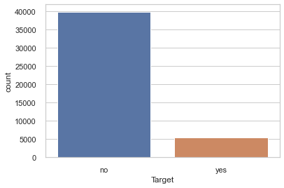

```python
sns.countplot(df['Target'])
```

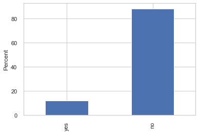

```python
x = df['Target']
ax = (pd.Series(x).value_counts(normalize=True, sort=False)*100).plot.bar()
ax.set(ylabel="Percent")
plt.show()
```

More than 80% of clients did not opt for term deposit in the last campaign

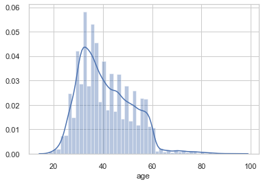

```python
sns.distplot(df['age'])
```

Client's age is concentrated around 25 - 40 years

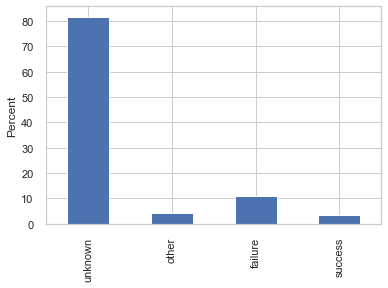

```python
x = df['poutcome']
ax = (pd.Series(x).value_counts(normalize=True, sort=False)*100).plot.bar()
ax.set(ylabel="Percent")
plt.show()
```

More than 80% of campaign outcome is unknown

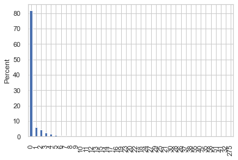

```python
x = df['previous']
ax = (pd.Series(x).value_counts(normalize=True, sort=True)*100).plot.bar()
ax.set(ylabel="Percent")
plt.show()
```

More than 80% of the clients were not contacted before the last campaign

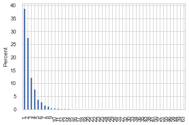

```python
x = df['campaign']
ax = (pd.Series(x).value_counts(normalize=True, sort=True)*100).plot.bar()
ax.set(ylabel="Percent")
plt.show()
```

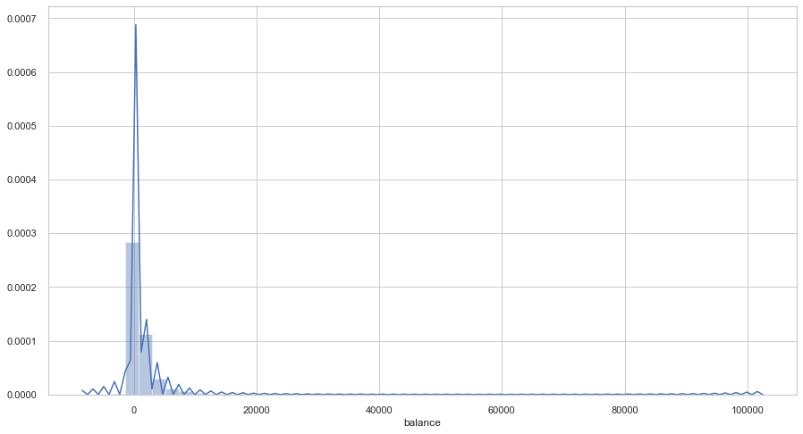

```python
 plt.figure(figsize = (15,8))
sns.distplot(df['balance'])
```

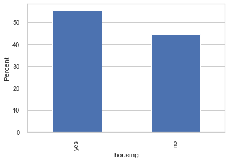

```python
 x = df['housing']
ax = (pd.Series(x).value_counts(normalize=True, sort=True)*100).plot.bar()
ax.set(ylabel="Percent",xlabel='housing')
plt.show()
```

Clients are well distributed between having and not having housing loan

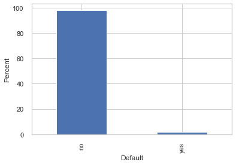

```python
x = df['default']
ax = (pd.Series(x).value_counts(normalize=True, sort=True)*100).plot.bar()
ax.set(ylabel="Percent",xlabel='Default')
plt.show()
```

Negligible amount of clients have defaulted loan

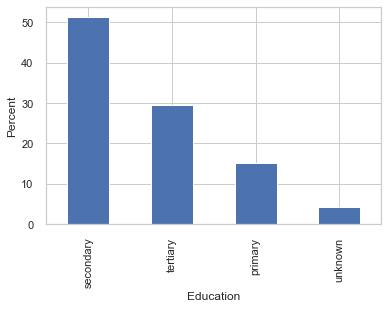

```python
x = df['education']
ax = (pd.Series(x).value_counts(normalize=True, sort=True)*100).plot.bar()
ax.set(ylabel="Percent",xlabel='Education')
plt.show()
```

Negligible amount of clients have not disclosed education, more than 50 % have secondary education, unknown can be merged with primary,

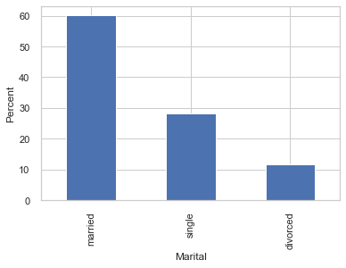

```python
x = df['marital']
ax = (pd.Series(x).value_counts(normalize=True, sort=True)*100).plot.bar()
ax.set(ylabel="Percent",xlabel='Marital')
plt.show()
```

More than 60% of clients are married. There are no unknown values in this column.

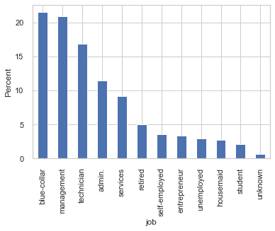

```python
x = df['job']
ax = (pd.Series(x).value_counts(normalize=True, sort=True)*100).plot.bar()
ax.set(ylabel="Percent",xlabel='job')
plt.show()
```

Client with blue-collar and management jobs are almost equally distributed. Unknown can be replaced with unemployed.

#### Multivariate Analysis

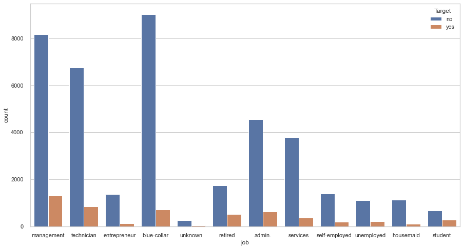

```python
 plt.figure(figsize = (15,8))
sns.countplot(df['job'],hue=df['Target'])
plt.show()
```

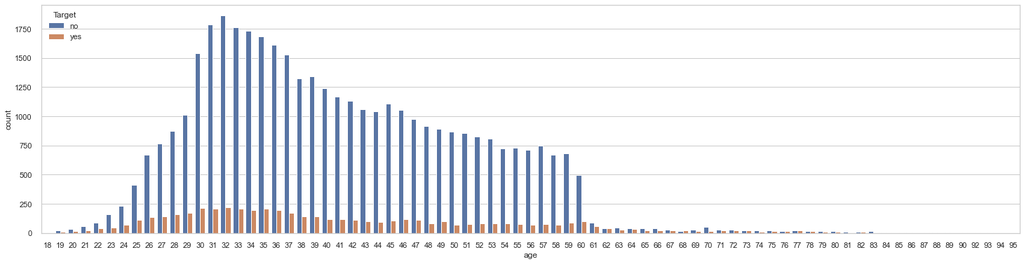

```python
 plt.figure(figsize = (25,6))
sns.countplot(df['age'],hue=df['Target'])
plt.show()
```

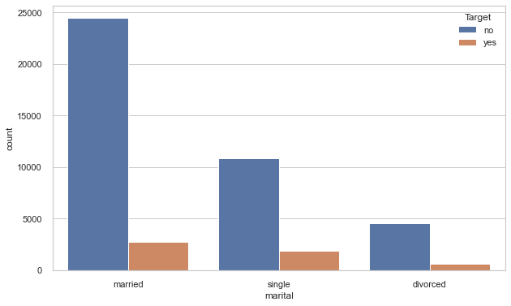

```python
 plt.figure(figsize = (10,6))
sns.countplot(df['marital'],hue=df['Target'])
plt.show()
```

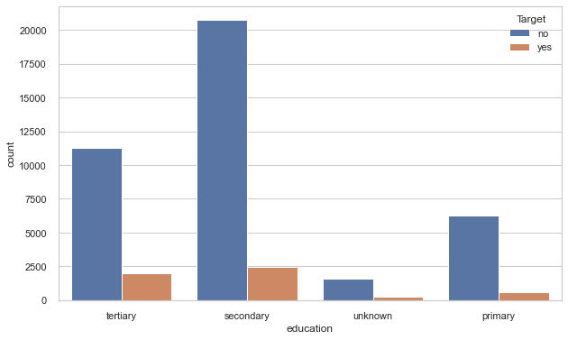

```python
 plt.figure(figsize = (10,6))
sns.countplot(df['education'],hue=df['Target'])
plt.show()
```

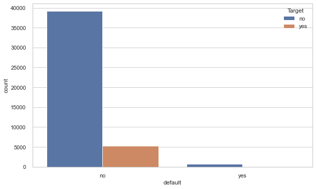

```python
plt.figure(figsize = (10,6))
sns.countplot(df['default'],hue=df['Target'])
plt.show()
```

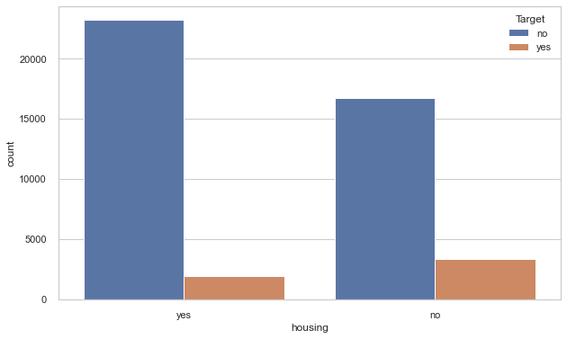

```python
 plt.figure(figsize = (10,6))
sns.countplot(df['housing'],hue=df['Target'])
```

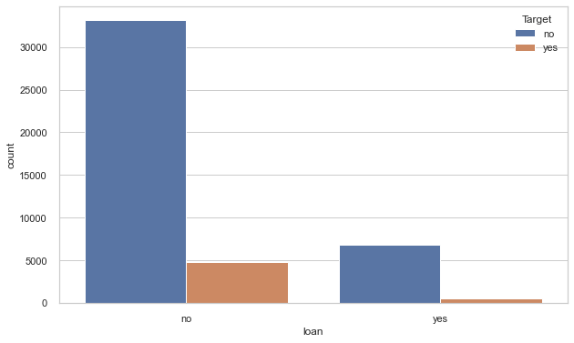

```python
 plt.figure(figsize = (10,6))
sns.countplot(df['loan'],hue=df['Target'])
```

Clients without personal loan have subscribed for term deposit.

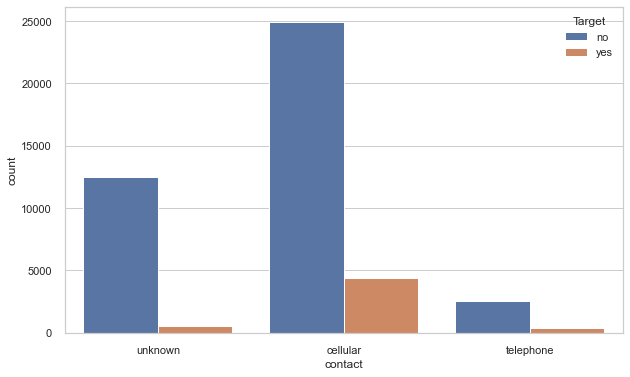

```python
 plt.figure(figsize = (10,6))
sns.countplot(df['contact'],hue=df['Target'])
```

Clients who were contacted by cellphone had highest term deposit subscription.

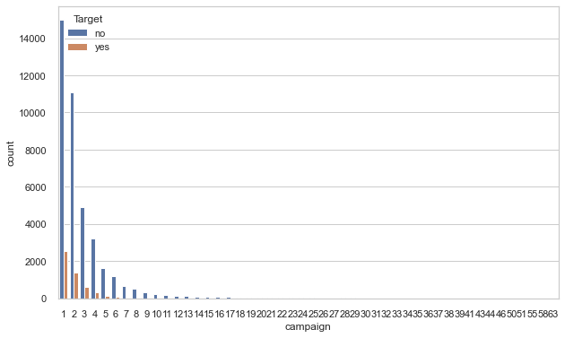

```python
 plt.figure(figsize = (10,6))
sns.countplot(df['campaign'],hue=df['Target'])
```

Clients who were contacted once, have highest term subsscriptions.

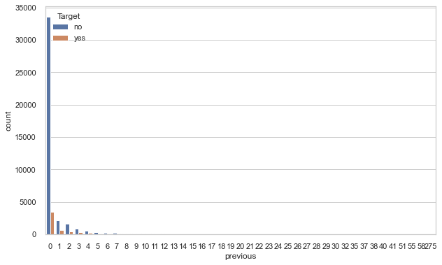

```python
 plt.figure(figsize = (10,6))
sns.countplot(df['previous'],hue=df['Target'])
```

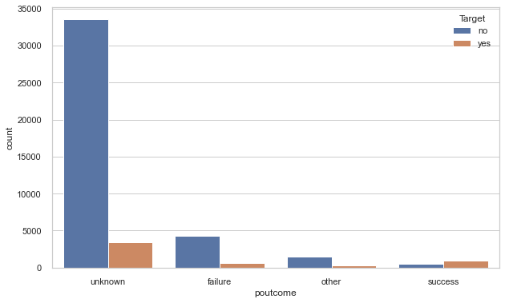

```python
 plt.figure(figsize = (10,6))
sns.countplot(df['poutcome'],hue=df['Target'])
```

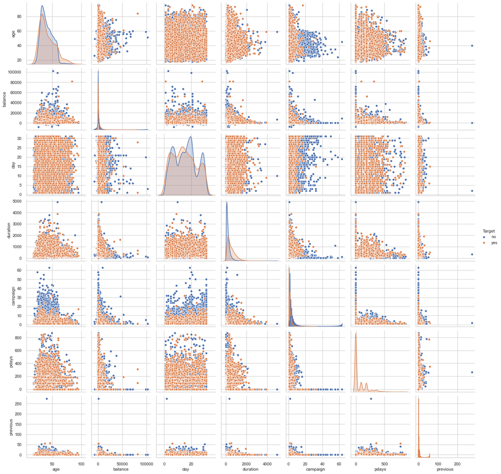

```python
sns.pairplot(df, hue='Target')
```

### Deliverable – 2 (Prepare the data for analytics) – (10)

```python
#importing the Encoding library
from sklearn.preprocessing import LabelEncoder
labelencoder_X=LabelEncoder()
df['job']=labelencoder_X.fit_transform(df['job'])
df['marital']=labelencoder_X.fit_transform(df['marital'])
df['education']=labelencoder_X.fit_transform(df['education'])
df['default']=labelencoder_X.fit_transform(df['default'])
df['housing']=labelencoder_X.fit_transform(df['housing'])
df['loan']=labelencoder_X.fit_transform(df['loan'])
df['contact']= labelencoder_X.fit_transform(df['contact'])
df['month']= labelencoder_X.fit_transform(df['month'])
df['poutcome'] = labelencoder_X.fit_transform(df['poutcome'])
df['Target'] = labelencoder_X.fit_transform(df['Target'])
```

```python
df.head()
```

|  | age | job | marital | education | default | balance | housing | loan | contact | day | month | duration | campaign | pdays | previous | poutcome | Target |
| --- | --- | --- | --- | --- | --- | --- | --- | --- | --- | --- | --- | --- | --- | --- | --- | --- | --- |
| 0 | 58 | 4 | 1 | 2 | 0 | 2143 | 1 | 0 | 2 | 5 | 8 | 261 | 1 | -1 | 0 | 3 | 0 |
| 1 | 44 | 9 | 2 | 1 | 0 | 29 | 1 | 0 | 2 | 5 | 8 | 151 | 1 | -1 | 0 | 3 | 0 |
| 2 | 33 | 2 | 1 | 1 | 0 | 2 | 1 | 1 | 2 | 5 | 8 | 76 | 1 | -1 | 0 | 3 | 0 |
| 3 | 47 | 1 | 1 | 3 | 0 | 1506 | 1 | 0 | 2 | 5 | 8 | 92 | 1 | -1 | 0 | 3 | 0 |
| 4 | 33 | 11 | 2 | 3 | 0 | 1 | 0 | 0 | 2 | 5 | 8 | 198 | 1 | -1 | 0 | 3 | 0 |

### Correlation method to observe the relationship between different variables.

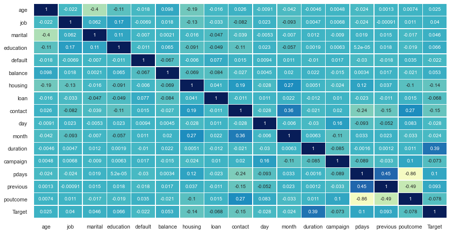

```python
plt.figure(figsize=(15,8))

sns.heatmap(df.corr(),
            annot=True,
            linewidths=.5,
            center=0,
            cbar=False,
            cmap="YlGnBu")

plt.show()
```

#### Split the dataset into training and test set in the ratio of 70:30 (Training:Test) based on dependent and independent variables.

```python
# splitting data into training and test set for independent attributes
from sklearn.model_selection import train_test_split

features = [col for col in df.columns if col != 'Target']

X_train, X_test, y_train, y_test = train_test_split(df[features], df['Target'], test_size=.3, random_state=22)
X_train.shape, X_test.shape
```

```
((31647, 16), (13564, 16))
```

### Deliverable – 3 (create the ensemble model)

#### 3.1 Logistic Regression

```python
from sklearn.linear_model import LogisticRegression
lr = LogisticRegression(random_state=7,solver='liblinear')
lr.fit(X_train, y_train)
```

```
LogisticRegression(random_state=7, solver='liblinear')
```

```python
y_predicted = lr.predict(X_test)
y_predicted.shape
```

```
(13564,)
```

```python
dfComp = pd.DataFrame()
dfComp['Actual'] = y_test.values
dfComp['Predicted'] = y_predicted
dfComp['Prob that o/p is 0'] = lr.predict_proba(X_test)[:,0]
dfComp['Prob that o/p is 1'] = lr.predict_proba(X_test)[:,1]
dfComp
```

|  | Actual | Predicted | Prob that o/p is 0 | Prob that o/p is 1 |
| --- | --- | --- | --- | --- |
| 0 | 0 | 0 | 0.99 | 0.01 |
| 1 | 0 | 0 | 0.99 | 0.01 |
| 2 | 1 | 0 | 0.74 | 0.26 |
| 3 | 0 | 0 | 0.93 | 0.07 |
| 4 | 0 | 0 | 0.98 | 0.02 |
| ... | ... | ... | ... | ... |
| 13559 | 0 | 0 | 0.99 | 0.01 |
| 13560 | 0 | 0 | 0.87 | 0.13 |
| 13561 | 0 | 0 | 0.95 | 0.05 |
| 13562 | 0 | 0 | 0.94 | 0.06 |
| 13563 | 0 | 0 | 0.91 | 0.09 |

13564 rows × 4 columns

```python
from sklearn.metrics import confusion_matrix,accuracy_score
#from sklearn.feature_selection import RFE # Feature ranking with recursive feature elimination.
from sklearn import metrics #  includes score functions, performance metrics and pairwise metrics and distance computations
from sklearn.metrics import classification_report, confusion_matrix # Build a text report showing the main classification metrics,Compute confusion matrix to evaluate the accuracy of a classification.
from sklearn.metrics import recall_score,precision_score,f1_score,roc_auc_score,accuracy_score
```

```python
cm = confusion_matrix(dfComp['Actual'],dfComp['Predicted'])
cm
```

```
array([[11725,   248],
       [ 1266,   325]], dtype=int64)
```

```python
# Evaluate model performance
print(classification_report(y_test, y_predicted))
```

```
              precision    recall  f1-score   support

           0       0.90      0.98      0.94     11973
           1       0.57      0.20      0.30      1591

    accuracy                           0.89     13564
   macro avg       0.73      0.59      0.62     13564
weighted avg       0.86      0.89      0.86     13564
```

```python
def draw_cm(actual,predicted):
    cm = confusion_matrix(actual,predicted)
    sns.heatmap(cm, annot=True, fmt ='.2f', xticklabels=[0,1],yticklabels=[0,1])
    plt.ylabel('observed')
    plt.xlabel ="predicted"
    plt.show()
```

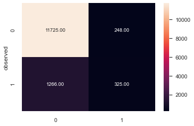

```python
draw_cm(dfComp['Actual'],dfComp['Predicted'])
```

```python
lr.get_params()
```

```
{'C': 1.0,
 'class_weight': None,
 'dual': False,
 'fit_intercept': True,
 'intercept_scaling': 1,
 'l1_ratio': None,
 'max_iter': 100,
 'multi_class': 'auto',
 'n_jobs': None,
 'penalty': 'l2',
 'random_state': 7,
 'solver': 'liblinear',
 'tol': 0.0001,
 'verbose': 0,
 'warm_start': False}
```

```python
from sklearn.model_selection import GridSearchCV
param_grid = [{'solver': ['newton-cg','lbfgs','liblinear','sag','saga'], 'C': [0.001,0.01,0.1,0.25,0.5,0.75,1],
              'class_weight':['balanced'], 'penalty':['l2']}]
grid_search = GridSearchCV(LogisticRegression(),param_grid,cv=5, verbose=0)
grid_search.fit(X_train,y_train)
grid_search.best_estimator_
```

[output not shown]

[output cut: 377 more lines]

[output not shown]

```
LogisticRegression(C=0.001, class_weight='balanced', solver='newton-cg')
```

```python
lrNew = LogisticRegression(C=0.001,random_state=7,solver='newton-cg',class_weight='balanced')
lrNew.fit(X_train, y_train)
```

```
LogisticRegression(C=0.001, class_weight='balanced', random_state=7,
                   solver='newton-cg')
```

```python
y_predicted = lrNew.predict(X_test)
dfCompNew = pd.DataFrame()
dfCompNew['Actual'] = y_test.values
dfCompNew['Predicted'] = y_predicted
dfCompNew['Prob that o/p is 0'] = lrNew.predict_proba(X_test)[:,0]
dfCompNew['Prob that o/p is 1'] = lrNew.predict_proba(X_test)[:,1]
dfCompNew
```

|  | Actual | Predicted | Prob that o/p is 0 | Prob that o/p is 1 |
| --- | --- | --- | --- | --- |
| 0 | 0 | 0 | 0.93 | 0.07 |
| 1 | 0 | 0 | 0.87 | 0.13 |
| 2 | 1 | 1 | 0.24 | 0.76 |
| 3 | 0 | 0 | 0.77 | 0.23 |
| 4 | 0 | 0 | 0.83 | 0.17 |
| ... | ... | ... | ... | ... |
| 13559 | 0 | 0 | 0.97 | 0.03 |
| 13560 | 0 | 1 | 0.46 | 0.54 |
| 13561 | 0 | 0 | 0.70 | 0.30 |
| 13562 | 0 | 0 | 0.69 | 0.31 |
| 13563 | 0 | 0 | 0.59 | 0.41 |

13564 rows × 4 columns

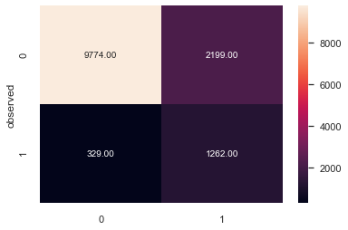

```python
draw_cm(dfCompNew['Actual'],dfCompNew['Predicted'])
```

```python
print(classification_report(y_test, y_predicted))
```

```
              precision    recall  f1-score   support

           0       0.97      0.82      0.89     11973
           1       0.36      0.79      0.50      1591

    accuracy                           0.81     13564
   macro avg       0.67      0.80      0.69     13564
weighted avg       0.90      0.81      0.84     13564
```

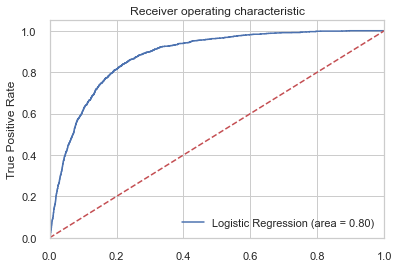

```python
from sklearn.metrics import roc_auc_score
from sklearn.metrics import roc_curve
logit_roc_auc = roc_auc_score(y_test, lrNew.predict(X_test))
fpr, tpr, thresholds = roc_curve(y_test, lrNew.predict_proba(X_test)[:,1])
plt.figure()
plt.plot(fpr, tpr, label='Logistic Regression (area = %0.2f)' % logit_roc_auc)
plt.plot([0, 1], [0, 1],'r--')
plt.xlim([0.0, 1.0])
plt.ylim([0.0, 1.05])
plt.xlabel ="False Positive Rate"
plt.ylabel('True Positive Rate')
plt.title('Receiver operating characteristic')
plt.legend(loc="lower right")
plt.savefig('Log_ROC')
plt.show()
```

```python
## Feature Importance or Coefficients
fi = pd.DataFrame()
fi['Col'] = X_train.columns
fi['Coeff'] = np.round(abs(lrNew.coef_[0]),2)
fi.sort_values(by='Coeff',ascending=False)
```

|  | Col | Coeff |
| --- | --- | --- |
| 6 | housing | 0.63 |
| 8 | contact | 0.52 |
| 7 | loan | 0.26 |
| 3 | education | 0.20 |
| 2 | marital | 0.17 |
| 14 | previous | 0.14 |
| 12 | campaign | 0.13 |
| 15 | poutcome | 0.12 |
| 4 | default | 0.03 |
| 1 | job | 0.02 |
| 10 | month | 0.02 |
| 0 | age | 0.01 |
| 9 | day | 0.01 |
| 5 | balance | 0.00 |
| 11 | duration | 0.00 |
| 13 | pdays | 0.00 |

```python
df.drop(['age','day','balance','duration','pdays'], axis = 1)
```

|  | job | marital | education | default | housing | loan | contact | month | campaign | previous | poutcome | Target |
| --- | --- | --- | --- | --- | --- | --- | --- | --- | --- | --- | --- | --- |
| 0 | 4 | 1 | 2 | 0 | 1 | 0 | 2 | 8 | 1 | 0 | 3 | 0 |
| 1 | 9 | 2 | 1 | 0 | 1 | 0 | 2 | 8 | 1 | 0 | 3 | 0 |
| 2 | 2 | 1 | 1 | 0 | 1 | 1 | 2 | 8 | 1 | 0 | 3 | 0 |
| 3 | 1 | 1 | 3 | 0 | 1 | 0 | 2 | 8 | 1 | 0 | 3 | 0 |
| 4 | 11 | 2 | 3 | 0 | 0 | 0 | 2 | 8 | 1 | 0 | 3 | 0 |
| ... | ... | ... | ... | ... | ... | ... | ... | ... | ... | ... | ... | ... |
| 45206 | 9 | 1 | 2 | 0 | 0 | 0 | 0 | 9 | 3 | 0 | 3 | 1 |
| 45207 | 5 | 0 | 0 | 0 | 0 | 0 | 0 | 9 | 2 | 0 | 3 | 1 |
| 45208 | 5 | 1 | 1 | 0 | 0 | 0 | 0 | 9 | 5 | 3 | 2 | 1 |
| 45209 | 1 | 1 | 1 | 0 | 0 | 0 | 1 | 9 | 4 | 0 | 3 | 0 |
| 45210 | 2 | 1 | 1 | 0 | 0 | 0 | 0 | 9 | 2 | 11 | 1 | 0 |

45211 rows × 12 columns

### 3.2 Decision Tree

```python
# invoking the decision tree classifier function. Using 'entropy' method of finding the split columns. Other option
# could be gini index.

model_entropy = DecisionTreeClassifier(criterion='entropy')
```

```python
model_entropy.fit(X_train, y_train)
```

```
DecisionTreeClassifier(criterion='entropy')
```

#### Print the accuracy of the model & print the confusion matrix

```python
print("Train: %.2f" % model_entropy.score(X_train, y_train))  # performance on train data
print("Test: %.2f" % model_entropy.score(X_test, y_test))  # performance on test data
```

```
Train: 1.00
Test: 0.88
```

- There is a high degree of overfitting in the model due to which the test accuracy drops drastically. This shows why decision trees are prone to overfitting.

#### Regularize/prune the decision tree by limiting the max. depth of trees and print the accuracy.

```python
clf_pruned = DecisionTreeClassifier(criterion = "entropy", max_depth=3)
clf_pruned.fit(X_train, y_train)
```

```
DecisionTreeClassifier(criterion='entropy', max_depth=3)
```

```python
print("Train: %.2f" % clf_pruned.score(X_train, y_train))  # performance on train data
print("Test: %.2f" % clf_pruned.score(X_test, y_test))  # performance on test data
```

```
Train: 0.89
Test: 0.89
```

#### Visualizing the tree

```python
y_train.value_counts()
```

```
0    27949
1     3698
Name: Target, dtype: int64
```

```python
from sklearn.tree import export_graphviz
from six import StringIO
from IPython.display import Image
import pydotplus
import graphviz
from sklearn import tree
```

```python
train_char_label = ['No', 'Yes']
Tree_File = open('termDeposit_tree.dot','w')
dot_data = tree.export_graphviz(clf_pruned, out_file=Tree_File, feature_names = list(X_train), class_names = list(train_char_label))
Tree_File.close()
```

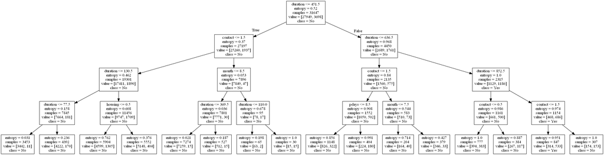

```python
display(Image("termDeposit_tree.png"))
```

```python
preds_train = clf_pruned.predict(X_train)
preds_test = clf_pruned.predict(X_test)

acc_DT = accuracy_score(y_test, preds_test)
```

#### Decision tree performance

```python
# Confusion matrix
pd.crosstab(y_test, preds_test, rownames=['Actual'], colnames=['Predicted'])
```

| Predicted Actual | 0 | 1 |
| --- | --- | --- |
| 0 | 11824 | 149 |
| 1 | 1380 | 211 |

```python
#Making the prediction
y_predict = clf_pruned.predict(X_test)
```

```python
# performance on train data
print('Performance on Training data using DT: ',clf_pruned.score(X_train , y_train))
# performance on test data
print('Performance on Testing data using DT: ',clf_pruned.score(X_test , y_test))
```

```
Performance on Training data using DT:  0.8900685689006856
Performance on Testing data using DT:  0.8872751400766735
```

```python
#Evaluate the model using accuracy, confusion metrix, and classification report
acc_DT=metrics.accuracy_score(y_test, y_predict)
print('Accuracy DT: ',acc_DT)
print('Confusion Matrix DT: \n',metrics.confusion_matrix(y_test, y_predict))
print('Classification report DT: \n',metrics.classification_report(y_test, y_predict))
```

```
Accuracy DT:  0.8872751400766735
Confusion Matrix DT:
 [[11824   149]
 [ 1380   211]]
Classification report DT:
               precision    recall  f1-score   support

           0       0.90      0.99      0.94     11973
           1       0.59      0.13      0.22      1591

    accuracy                           0.89     13564
   macro avg       0.74      0.56      0.58     13564
weighted avg       0.86      0.89      0.85     13564
```

```python
#Store the accuracy results for each model in a dataframe for final comparison
results = pd.DataFrame({'Method':['Decision Tree'], 'accuracy': acc_DT},index={'1'})
results = results[['Method', 'accuracy']]
results
```

|  | Method | accuracy |
| --- | --- | --- |
| 1 | Decision Tree | 0.89 |

```python
from yellowbrick.classifier import ClassificationReport, ROCAUC
```

```
ROCAUC(ax=<matplotlib.axes._subplots.AxesSubplot object at 0x00000252C32D7130>,
       binary=None, model=None)
```

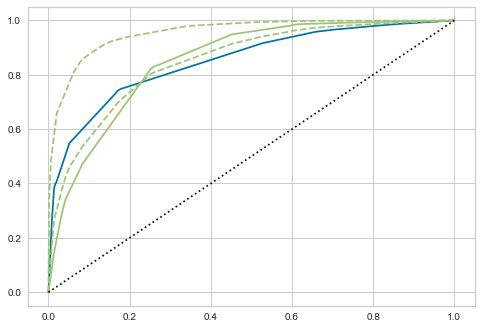

```python
roc = ROCAUC(DecisionTreeClassifier(criterion = "entropy", max_depth=4))
roc.fit(X_train, y_train)
roc.score(X_test, y_test)
roc
```

```python
df[features]
```

|  | age | job | marital | education | default | balance | housing | loan | contact | day | month | duration | campaign | pdays | previous | poutcome |
| --- | --- | --- | --- | --- | --- | --- | --- | --- | --- | --- | --- | --- | --- | --- | --- | --- |
| 0 | 58 | 4 | 1 | 2 | 0 | 2143 | 1 | 0 | 2 | 5 | 8 | 261 | 1 | -1 | 0 | 3 |
| 1 | 44 | 9 | 2 | 1 | 0 | 29 | 1 | 0 | 2 | 5 | 8 | 151 | 1 | -1 | 0 | 3 |
| 2 | 33 | 2 | 1 | 1 | 0 | 2 | 1 | 1 | 2 | 5 | 8 | 76 | 1 | -1 | 0 | 3 |
| 3 | 47 | 1 | 1 | 3 | 0 | 1506 | 1 | 0 | 2 | 5 | 8 | 92 | 1 | -1 | 0 | 3 |
| 4 | 33 | 11 | 2 | 3 | 0 | 1 | 0 | 0 | 2 | 5 | 8 | 198 | 1 | -1 | 0 | 3 |
| ... | ... | ... | ... | ... | ... | ... | ... | ... | ... | ... | ... | ... | ... | ... | ... | ... |
| 45206 | 51 | 9 | 1 | 2 | 0 | 825 | 0 | 0 | 0 | 17 | 9 | 977 | 3 | -1 | 0 | 3 |
| 45207 | 71 | 5 | 0 | 0 | 0 | 1729 | 0 | 0 | 0 | 17 | 9 | 456 | 2 | -1 | 0 | 3 |
| 45208 | 72 | 5 | 1 | 1 | 0 | 5715 | 0 | 0 | 0 | 17 | 9 | 1127 | 5 | 184 | 3 | 2 |
| 45209 | 57 | 1 | 1 | 1 | 0 | 668 | 0 | 0 | 1 | 17 | 9 | 508 | 4 | -1 | 0 | 3 |
| 45210 | 37 | 2 | 1 | 1 | 0 | 2971 | 0 | 0 | 0 | 17 | 9 | 361 | 2 | 188 | 11 | 1 |

45211 rows × 16 columns

#### Feature Importance

```python
## Calculating feature importance

feat_importance = clf_pruned.tree_.compute_feature_importances(normalize=False)


feat_imp_dict = dict(zip(features, clf_pruned.feature_importances_))
feat_imp = pd.DataFrame.from_dict(feat_imp_dict, orient='index')
feat_imp.sort_values(by=0, ascending=False)
```

|  | 0 |
| --- | --- |
| duration | 0.71 |
| contact | 0.19 |
| housing | 0.08 |
| month | 0.02 |
| pdays | 0.01 |
| age | 0.00 |
| job | 0.00 |
| marital | 0.00 |
| education | 0.00 |
| default | 0.00 |
| balance | 0.00 |
| loan | 0.00 |
| day | 0.00 |
| campaign | 0.00 |
| previous | 0.00 |
| poutcome | 0.00 |

- From the feature importance dataframe we can infer Duration has the highest impact and followed by contact.

```python
#Store the accuracy results for each model in a dataframe for final comparison
resultsDf = pd.DataFrame({'Method':['Decision Tree'], 'accuracy': acc_DT},index={'1'})
resultsDf = resultsDf[['Method', 'accuracy']]
resultsDf
```

|  | Method | accuracy |
| --- | --- | --- |
| 1 | Decision Tree | 0.89 |

### 3.2 Ensemble Models

#### Random Forest

```python
from sklearn.ensemble import RandomForestClassifier
rfcl = RandomForestClassifier(n_estimators = 50)
rfcl = rfcl.fit(X_train, y_train)
```

```python
pred_RF = rfcl.predict(X_test)
acc_RF = accuracy_score(y_test, pred_RF)
```

```python
tempResultsDf = pd.DataFrame({'Method':['Random Forest'], 'accuracy': [acc_RF]},index={'2'})
resultsDf = pd.concat([resultsDf, tempResultsDf])
resultsDf = resultsDf[['Method', 'accuracy']]
resultsDf
```

|  | Method | accuracy |
| --- | --- | --- |
| 1 | Decision Tree | 0.89 |
| 2 | Random Forest | 0.91 |

```
ClassificationReport(ax=<matplotlib.axes._subplots.AxesSubplot object at 0x00000252CB14AEE0>,
                     cmap=<matplotlib.colors.ListedColormap object at 0x00000252CB14E760>,
                     model=None)
```

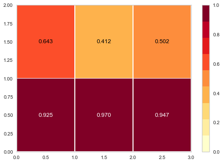

```python
# Visualize model performance with yellowbrick library
viz = ClassificationReport(RandomForestClassifier(n_estimators = 50))
viz.fit(X_train, y_train)
viz.score(X_test, y_test)
viz
```

```
ROCAUC(ax=<matplotlib.axes._subplots.AxesSubplot object at 0x00000252CB1FD580>,
       binary=None, model=None)
```

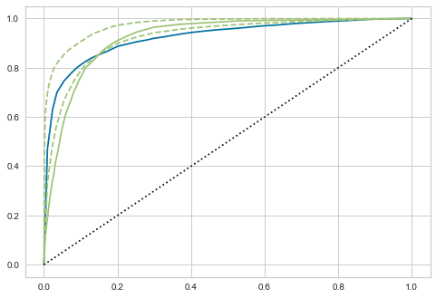

```python
roc = ROCAUC(RandomForestClassifier(n_estimators = 50))
roc.fit(X_train, y_train)
roc.score(X_test, y_test)
roc
```

## Apply Adaboost Ensemble Algorithm for the same data and print the accuracy.

```python
from sklearn.ensemble import AdaBoostClassifier
abcl = AdaBoostClassifier(n_estimators = 100, learning_rate=0.1, random_state=22)
abcl = abcl.fit(X_train, y_train)
```

```python
pred_AB =abcl.predict(X_test)
acc_AB = accuracy_score(y_test, pred_AB)
```

```python
tempResultsDf = pd.DataFrame({'Method':['Adaboost'], 'accuracy': [acc_AB]},index={'3'})
resultsDf = pd.concat([resultsDf, tempResultsDf])
resultsDf = resultsDf[['Method', 'accuracy']]
resultsDf
```

|  | Method | accuracy |
| --- | --- | --- |
| 1 | Decision Tree | 0.89 |
| 2 | Random Forest | 0.91 |
| 3 | Adaboost | 0.89 |

```
ClassificationReport(ax=<matplotlib.axes._subplots.AxesSubplot object at 0x00000252CB26AEB0>,
                     cmap=<matplotlib.colors.ListedColormap object at 0x00000252C5DB25B0>,
                     model=None)
```

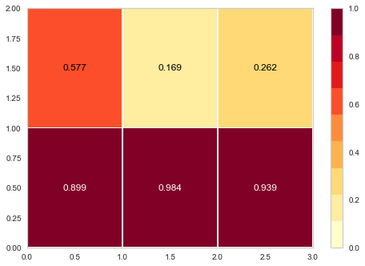

```python
# Visualize model performance with yellowbrick library
viz = ClassificationReport(AdaBoostClassifier(n_estimators= 100, learning_rate=0.1, random_state=22))
viz.fit(X_train, y_train)
viz.score(X_test, y_test)
viz
```

```
ROCAUC(ax=<matplotlib.axes._subplots.AxesSubplot object at 0x00000252CAF7C280>,
       binary=None, model=None)
```

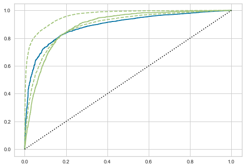

```python
roc = ROCAUC(AdaBoostClassifier(n_estimators= 100, learning_rate=0.1, random_state=22))
roc.fit(X_train, y_train)
roc.score(X_test, y_test)
roc
```

### Apply Bagging Classifier Algorithm and print the accuracy.

```python
from sklearn.ensemble import BaggingClassifier

bgcl = BaggingClassifier(n_estimators=50, max_samples= .7, bootstrap=True, oob_score=True, random_state=22)
bgcl = bgcl.fit(X_train, y_train)
```

```python
pred_BG = bgcl.predict(X_test)
acc_BG = accuracy_score(y_test, pred_BG)
```

```python
tempResultsDf = pd.DataFrame({'Method':['Bagging'], 'accuracy': [acc_BG]},index={'4'})
resultsDf = pd.concat([resultsDf, tempResultsDf])
resultsDf = resultsDf[['Method', 'accuracy']]
resultsDf
```

|  | Method | accuracy |
| --- | --- | --- |
| 1 | Decision Tree | 0.89 |
| 2 | Random Forest | 0.91 |
| 3 | Adaboost | 0.89 |
| 4 | Bagging | 0.90 |

```
ClassificationReport(ax=<matplotlib.axes._subplots.AxesSubplot object at 0x00000252C5C77C40>,
                     cmap=<matplotlib.colors.ListedColormap object at 0x00000252C5C77B50>,
                     model=None)
```

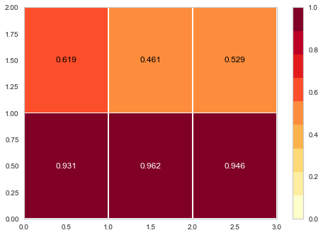

```python
# Visualize model performance with yellowbrick library
viz = ClassificationReport(BaggingClassifier(n_estimators=50, max_samples= .7, bootstrap=True, oob_score=True, random_state=22))
viz.fit(X_train, y_train)
viz.score(X_test, y_test)
viz
```

```
ROCAUC(ax=<matplotlib.axes._subplots.AxesSubplot object at 0x00000252C5AEDFD0>,
       binary=None, model=None)
```

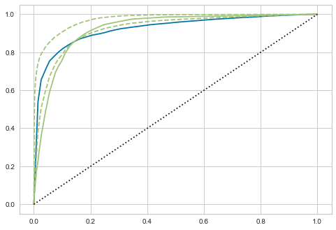

```python
roc = ROCAUC(BaggingClassifier(n_estimators=50, max_samples= .7, bootstrap=True, oob_score=True, random_state=22))
roc.fit(X_train, y_train)
roc.score(X_test, y_test)
roc
```

### Apply GradientBoost Classifier Algorithm for the same data and print the accuracy

```python
from sklearn.ensemble import GradientBoostingClassifier
gbcl = GradientBoostingClassifier(n_estimators = 50, learning_rate = 0.1, random_state=22)
gbcl = gbcl.fit(X_train, y_train)
```

```python
pred_GB = gbcl.predict(X_test)
acc_GB = accuracy_score(y_test, pred_GB)
```

```python
tempResultsDf = pd.DataFrame({'Method':['Gradient Boost'], 'accuracy': [acc_GB]},index={'5'})
resultsDf = pd.concat([resultsDf, tempResultsDf])
resultsDf = resultsDf[['Method', 'accuracy']]
resultsDf
```

|  | Method | accuracy |
| --- | --- | --- |
| 1 | Decision Tree | 0.89 |
| 2 | Random Forest | 0.91 |
| 3 | Adaboost | 0.89 |
| 4 | Bagging | 0.90 |
| 5 | Gradient Boost | 0.90 |

```
ClassificationReport(ax=<matplotlib.axes._subplots.AxesSubplot object at 0x00000252C5B05A30>,
                     cmap=<matplotlib.colors.ListedColormap object at 0x00000252C5B3A550>,
                     model=None)
```

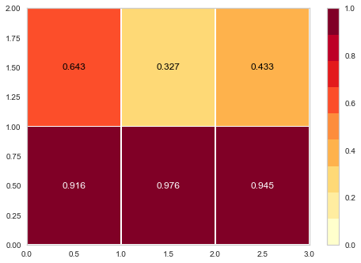

```python
# Visualize model performance with yellowbrick library
viz = ClassificationReport(GradientBoostingClassifier(n_estimators = 50, learning_rate = 0.1, random_state=22))
viz.fit(X_train, y_train)
viz.score(X_test, y_test)
viz
```

```
ROCAUC(ax=<matplotlib.axes._subplots.AxesSubplot object at 0x00000252CB0B3B50>,
       binary=None, model=None)
```

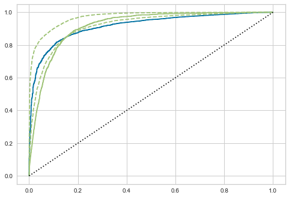

```python
roc = ROCAUC(GradientBoostingClassifier(n_estimators = 50, learning_rate = 0.1, random_state=22))
roc.fit(X_train, y_train)
roc.score(X_test, y_test)
roc
```

#### For this dataset, Random forest and bagging models give the best results on test predictions

```python
# Creating a function for visualizing classifier results
def ClassifierResults(model_w_parameters):
    viz = ClassificationReport(model_w_parameters)
    viz.fit(X_train, y_train)
    viz.score(X_test, y_test)
    viz

def ROCAUCscore(model_w_parameters):
    roc = ROCAUC(model_w_parameters)
    roc.fit(X_train, y_train)
    roc.score(X_test, y_test)
    roc
```

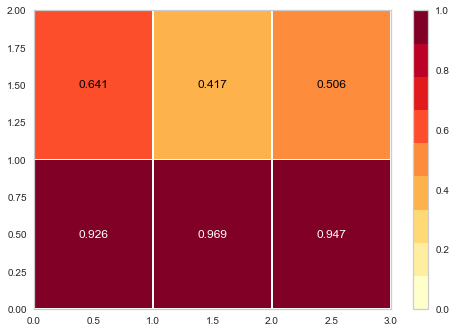

```python
ClassifierResults(RandomForestClassifier(n_estimators = 50))
```

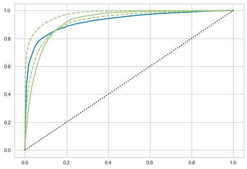

```python
ROCAUCscore(RandomForestClassifier(n_estimators = 50))
```

```python
#Multiple model Ensemble
from sklearn import svm
LR=LogisticRegression()
NB=GaussianNB()
#DT=DecisionTreeClassifier()  ('DT',DT),
SVM=svm.SVC()
```

```python
evc=VotingClassifier(estimators=[('LR',LR),('NB',NB),('SVM',SVM)],voting='hard')
evc.fit(X_train, y_train)
```

```
VotingClassifier(estimators=[('LR', LogisticRegression()), ('NB', GaussianNB()),
                             ('SVM', SVC())])
```

```python
y_predict = evc.predict(X_test)
acc_Ensemble=metrics.accuracy_score(y_test, y_predict)
print('Accuracy using Ensemble: ',acc_Ensemble)
```

```
Accuracy using Ensemble:  0.8861692716012975
```

```python
tempResultsDf = pd.DataFrame({'Method':['Ensemble'], 'accuracy': [acc_Ensemble]},index={'6'})
results = pd.concat([resultsDf, tempResultsDf])
results = results[['Method', 'accuracy']]
results
```

|  | Method | accuracy |
| --- | --- | --- |
| 1 | Decision Tree | 0.89 |
| 2 | Random Forest | 0.91 |
| 3 | Adaboost | 0.89 |
| 4 | Bagging | 0.90 |
| 5 | Gradient Boost | 0.90 |
| 6 | Ensemble | 0.89 |

## Business Insights

#### Model Performance

- Random forest technique has the highest accuracy.

#### Business Insights

- True Positive (observed=1,predicted=1): Model predicted that 1262 customers will take Term Deposit and they customer took it
- False Positive (observed=0,predicted=1): Model Predicted 2199 customers will take Term Deposit and the customer did not take it but bank didn't loose any money
- True Negative (observed=0,predicted=0): Model Predicted 9774 customers will not take Term Deposit and and the customer did not take it
- False Negative (observed=1,predicted=0): Model Predicted 329 customers will not take Term Deposit and the customer took it - Model needs an improvement here.
- Since the bank need more Term Deposit customer and bank does not want to lose customer, focus should be on "Recall"